# ML_Assignment_1

# Question 4

```r
#Z-score transformation

mobileChurnDF$VoiceMinutes_Z = scale(mobileChurnDF$VoiceMinutes)
summary(mobileChurnDF$VoiceMinutes_Z)
```

```
##        V1
##  Min.   :-1.81571
##  1st Qu.:-0.83084
##  Median : 0.04372
##  Mean   : 0.00000
##  3rd Qu.: 0.81309
##  Max.   : 1.72410
```

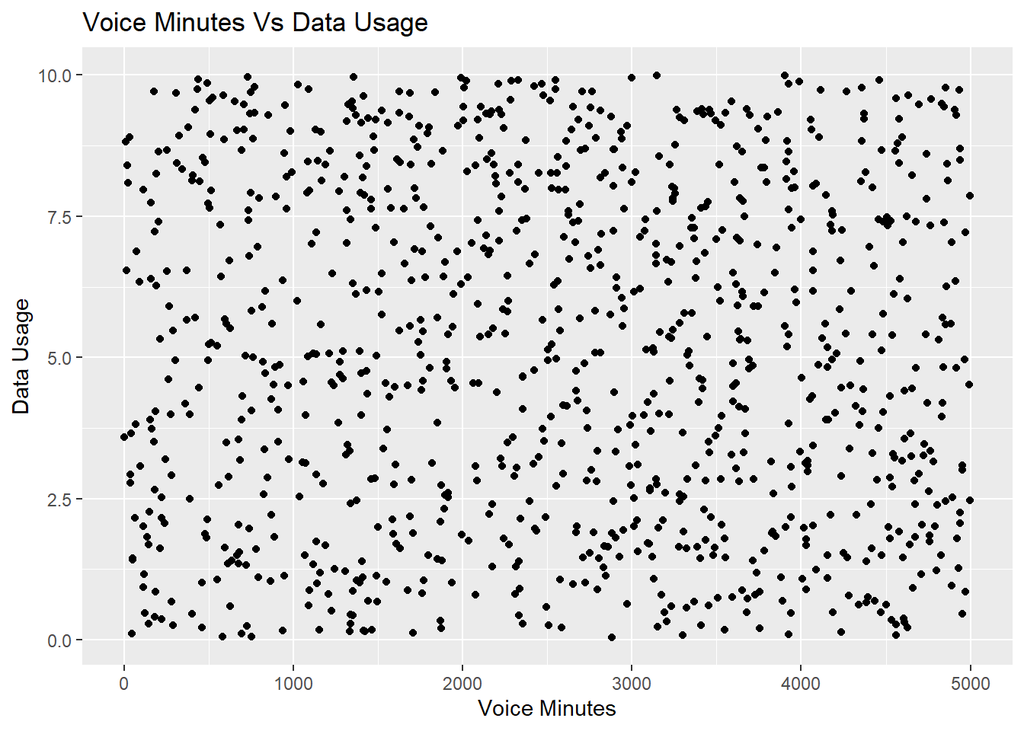

```r
ggplot(mobileChurnDF) + geom_point(aes(x = mobileChurnDF$VoiceMinutes, y = mobileChurnDF$DataUsage)) + ggtitle("Voice Minutes Vs Data Usage") + xlab("Voice Minutes") + ylab("Data Usage")
```

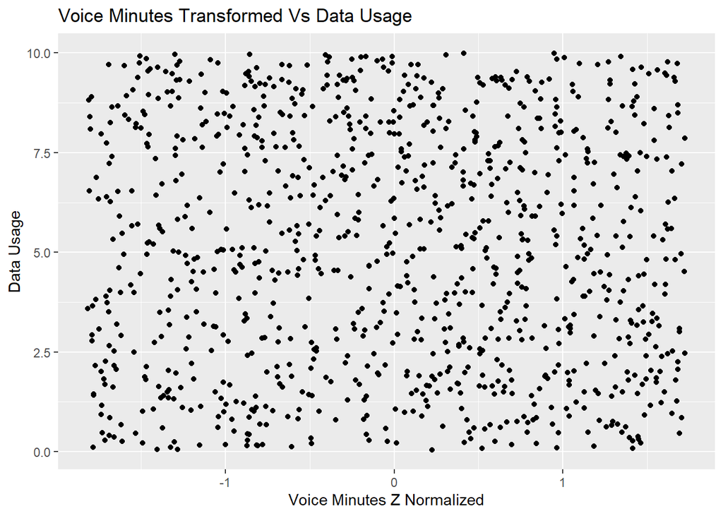

```r
ggplot(mobileChurnDF) + geom_point(aes(x = mobileChurnDF$VoiceMinutes_Z, y = mobileChurnDF$DataUsage)) + ggtitle("Voice Minutes Transformed Vs Data Usage") + xlab("Voice Minutes Z Normalized") + ylab("Data Usage")
```

# Question 4 Insights

With out knowing what this data will be used for I decided to transform the VoiceMinutes Variable in order to decrease it’s range. This happens by transforming the data to have a mean of 0 and a standard deviation of 1. Voice Minutes ranges from 1.91 Minutes to 4998.7 Minutes. This is a wide range as well as much larger numbers when compared to the rest of the variables. Changing the scale did not change the distribution of the data as can be seen in the two charts. The first is using the original VoiceMinutes while the second chart uses the transformed VoiceMinutes_Z.